# SFO Airport Traffic Time Series Analysis

This project aims to build a predictive model to forecast SFO airport monthly passenger traffic in 2017 with highest possible accuracy, given monthly data from January 2006 to December 2016 on SFO monly airport traffic (including departure, arrival and transit), fuel prices, passenger flight traffic, monthly rainfall and consumer price index in San Francisco, then selected the optimal model and used it for forecasting.

Let’s will first explore the data：

## Data Overview:

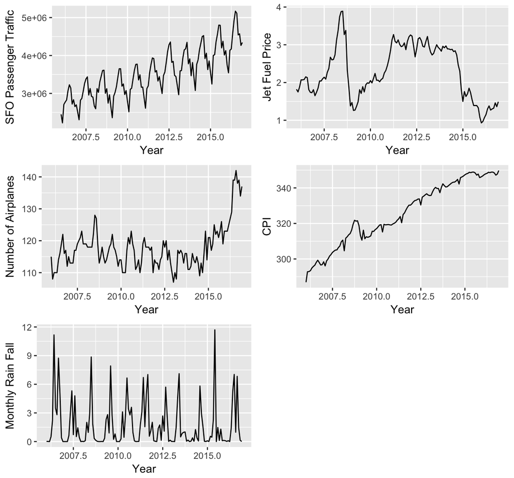

To explore the relationship between the 5 variables, we constructed a correlation matrix. We can see that passenger traffic is highly correlated with CPI and is somewhat correlated with flight traffic. Flight traffic rate has a smaller, and negative, correlation with fuel price. Variables with medium to high correlation are of interest because they can possibly be used as covariates to help accurately predict passenger traffic.

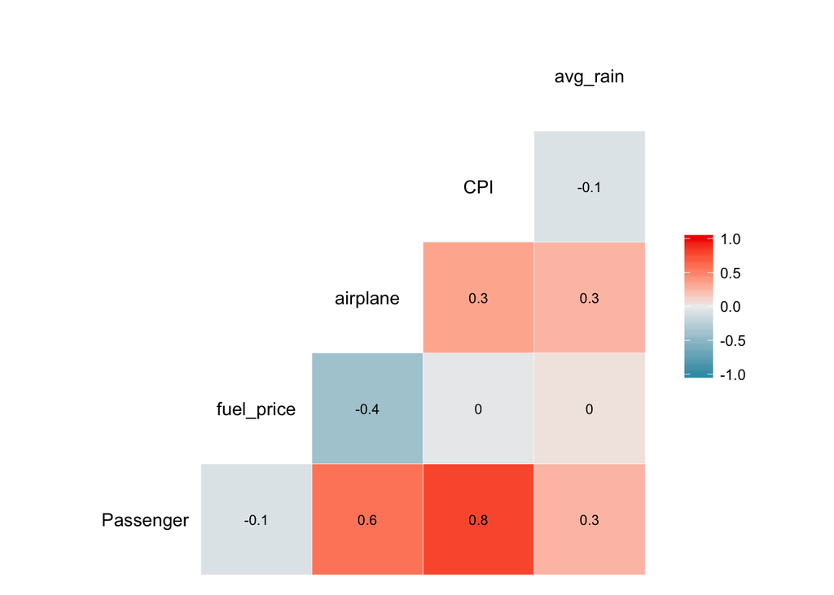

## Method

In order to find the best model, we split our training data into training and validation set. The training set consists of observations from January 2006 to December 2015, and is used for constructing the models. The last 1-year of data (12 observations) is held out to determine the predictive accuracy of the model.

We explored the following methods for modeling the traffic passenger data:

• Box-Jenkins Methods: including ARIMA, SARIMA and SARIMAX, this approach works by removing the trend and seasonality through differencing the data and modeling the transformed data.

• Holt-Winters model: this approach works by assigning exponentially decreasing weights to older observations. Considering the trend and seasonality pattern observed in the data, we used triple exponential smoothing for modeling.

• VAR: this approach works by treating the other influential variables as endogenous variable - they influence bankruptcy rate and bankruptcy rate influences them.

### Box-Jenkins Methods

Box-Jenkin models involves statistical theory and modeling to analyze and forecast time series data. The naming standard for the various types of time series models consists of acronyms defined as the following:

- **S:** *Seasonal* effects - in our case, monthly
- **AR:** *Autoregressive* is a stochastic process in which future predictions are based on a weighted sum of previous observations
- **I:** *Integrated* involves ordinary differencing, or subtracting observations from the previous observation in time, to make a time series stationary (mean, variance, autocorrelation constant over time)
- **MA:** *Moving Average* is an average over many past observations
- **X:** e*X*ogenous variables are external variables that influence the response variable but the responsen does not influence them (Example: BART ridership may be affected by weather, but weather does not depend on BART ridership)

So, SARIMAX means *Seasonal Autoregressive Integrated Moving Average with Exogenous Variables*

In this part， we will explore SARIMA and SARIMAX models in order to predict bankruptcy rate. SARIMA models are univariate models which depend on previous observations and try to predict future values. SARIMAX on the other hand is a multivariate time series model which has the SARIMA component but also regresses on the given multivariate data at time $t$.

### SARIMA MODEL (Univariate Airport Passenger Traffic)

Plot training data

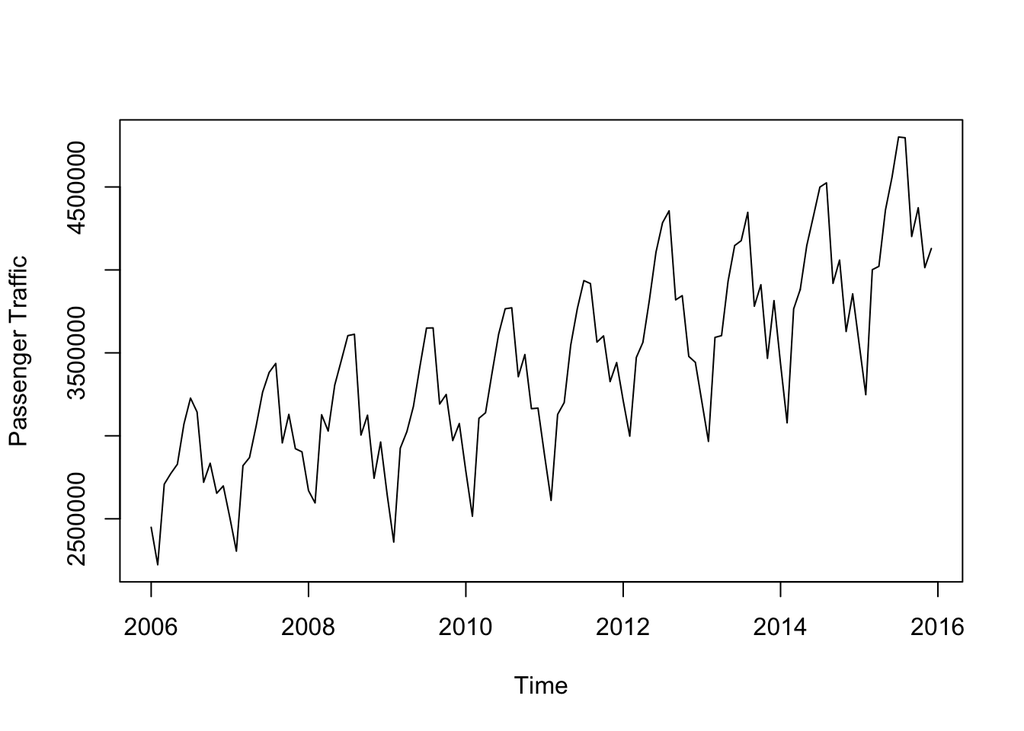

ACF plot suggested seasonality.

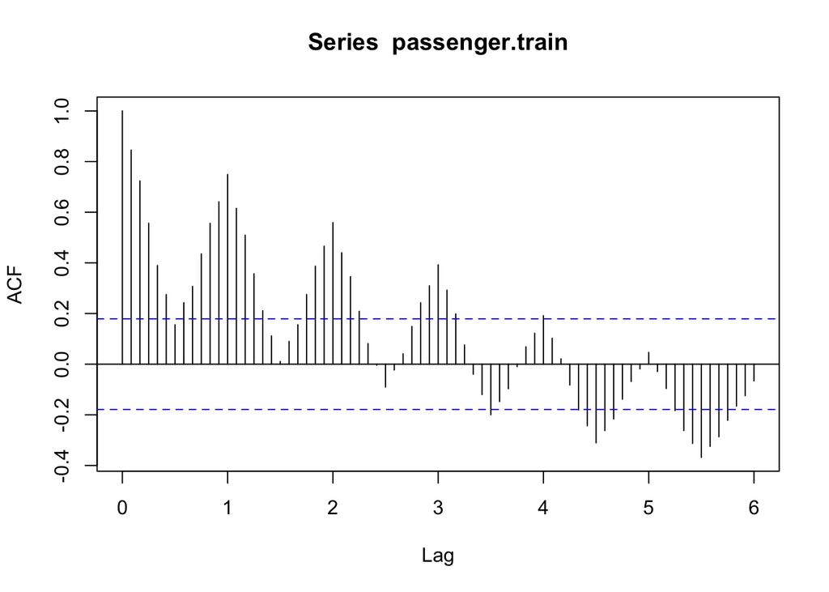

ADF test also suggested non-stationary.

```
##
##  Augmented Dickey-Fuller Test
##
## data:  passenger.train
## Dickey-Fuller = -1.6351, Lag order = 12, p-value = 0.7281
## alternative hypothesis: stationary
```

Let’s try differencing the time series for trend and seasonality.

```
##
##  Augmented Dickey-Fuller Test
##
## data:  train1.12
## Dickey-Fuller = -5.0845, Lag order = 12, p-value = 0.01
## alternative hypothesis: stationary
```

Now after differencing, the data is stationary. so d =1, D=1, s=12. Plot ACF and PACF to determine the other parameters. p=0, q=1, P=1, Q=1

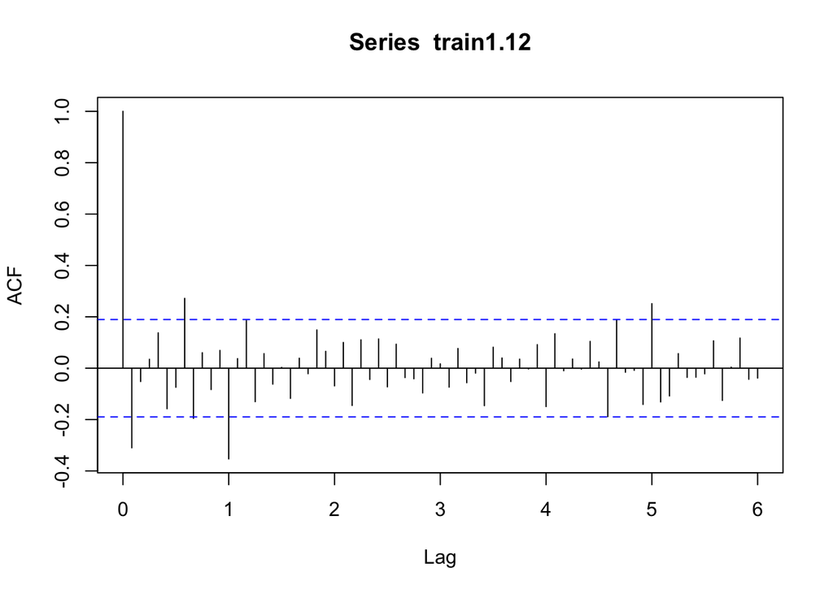

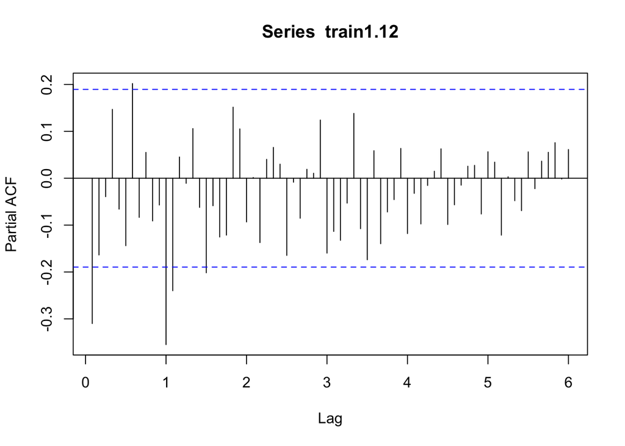

```
##
## Call:
## arima(x = passenger.train, order = c(0, 1, 1), seasonal = list(order = c(1,
##     1, 1), period = 12), method = "CSS-ML")
##
## Coefficients:
##           ma1    sar1     sma1
##       -0.3692  0.0316  -0.6014
## s.e.   0.0895  0.1646   0.1479
##
## sigma^2 estimated as 5.961e+09:  log likelihood = -1358.57,  aic = 2725.14
```

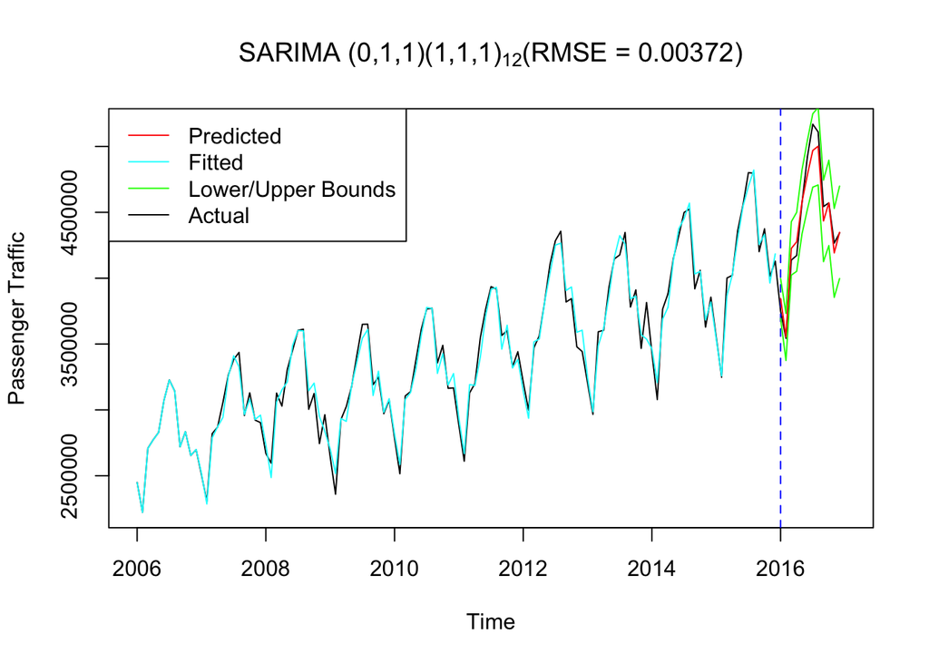

### Checking Box-Jenkins Assumptions

Box-Jenkins models relies on the following assumptions regarding the residuals (difference between actual - predicted) for the models to be valid.

- Zero-Mean: the residuals have a mean of zero
- Homoscedasticity: the residuals have constant variance
- Zero-Correlation: the residuals are uncorrelated
- Normality: the residuals are normally distributed (no need to check for our subset model which is based on Least Squares rather than Maximum Likelihood Estimation)

#### Residual Diagnostics

##### Zero Mean:

Performed a sample t test for the true mean residuals. p-value = 0.5592 > 0.05  
We cannnot reject the null hypothesis, so Zero-Mean assumption is satisfied.

```
##
##  One Sample t-test
##
## data:  e
## t = 0.58565, df = 119, p-value = 0.5592
## alternative hypothesis: true mean is not equal to 0
## 95 percent confidence interval:
##  -9306.579 17123.828
## sample estimates:
## mean of x
##  3908.625
```

##### Homoscedasticity:

We first look at the scatter plot of the residual against t. The residuals appears to be randomly scattered, suggesting the homoscedasticity assumption. should be valid

To formally test the assumption, the p-value for Levene’s test is greater than 0.05. Therefore, we cannot reject the null hypothesis. Therefore, the Homoscedasticity assumption is met.

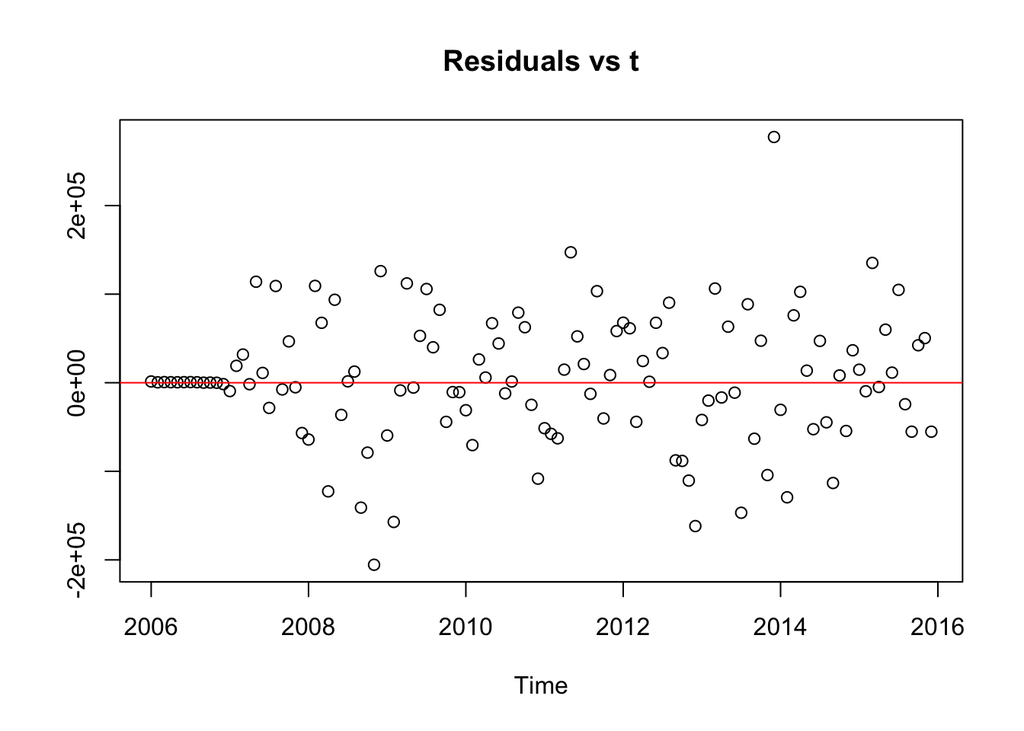

```
## Levene's Test for Homogeneity of Variance (center = median)
##        Df F value Pr(>F)
## group   3  0.3779 0.7692
##       104
```

##### Zero-Correlation:

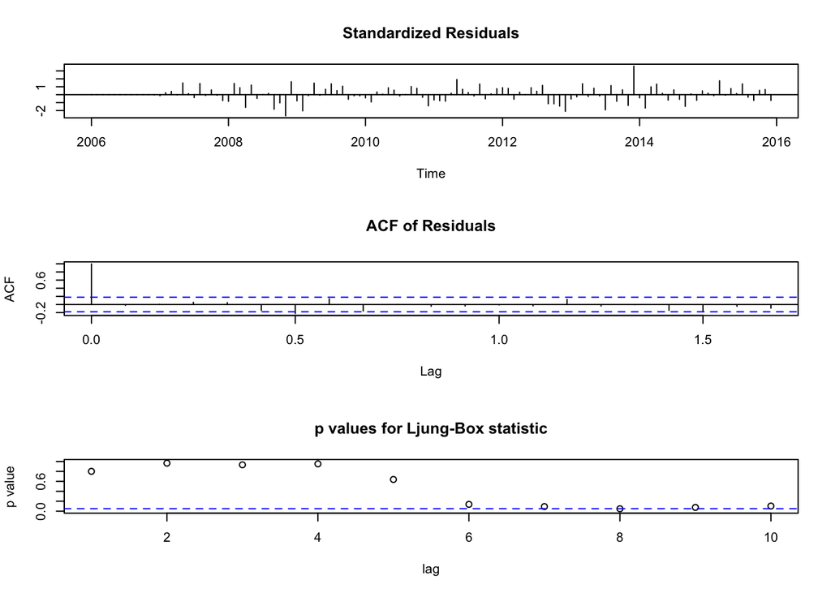

##### Normality:

The q-q plot shows that the residual quantiles do not match well with the theoretical normal quantiles, especially at tail.

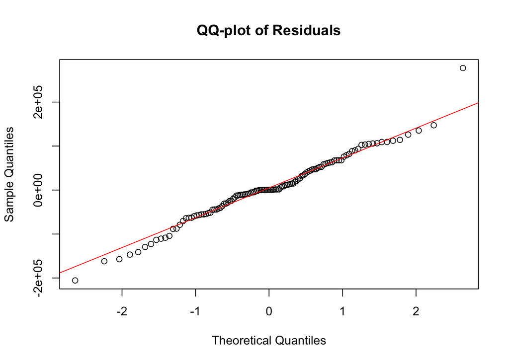

```
##
##  Shapiro-Wilk normality test
##
## data:  e
## W = 0.97911, p-value = 0.05883
```

Through formal hypothesis testing, the SARIMA models satisfied the assumptions.

### SARIMAX

In this part we will use exgenous data, assuming that there is a uni-directional relationship, meaning only independent variables effect bankruptcy not the other way around.

Our final best model is SARIMAX(0,1,1)(1,1,1)<sub>12</sub>, with a rmse of ~95754.77 by using exogenous variables: flight traffic and CPI. Overall, this provides a better performance than using the univariate model. flight traffic and CPI data do add extra information to our model and provided better prediction results on the validation data.

Retraining the model with the full training data

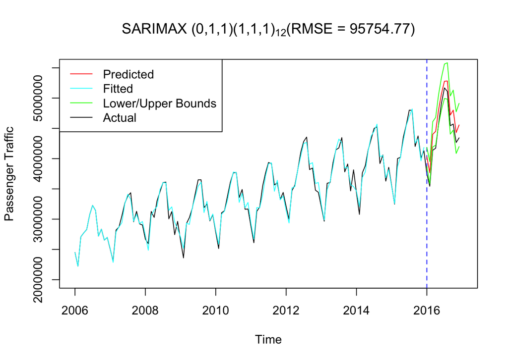

### Holt-Winters Methods

Holt-Winters Methods involves an exponentially weighted moving average. In the context of the Canadian bankruptcy rates, our model’s predictions are based on averages of previously observed bankruptcy rates, with more weight on recent data. In other words, last month is a better indicator than say, 10 years ago. This makes sense because bankruptcy rates is most certainly going to change over time. Triple Exponential Smoothing is appropriate for forecasting monthly bankruptcy rates for Canada because there is both **trend** and **seasonality**.

**Trend:** A trend exists if there is a long-term increase or decrease in bankruptcy rates.

**Seasonality:** Seasonality is when the time series exhibits similar behavior at regular intervals, or *seasons*. In our scenario, bankruptcy rates are recorded every month, and therefore the period of a season is 12 months (1 year).

Furthermore, we choose to use an *additive* method because the size of the peaks are roughly the same throughout the time series. There are three parameters to be estimated: $\alpha$, $\beta$, and $\gamma$.

```
## Holt-Winters exponential smoothing with trend and additive seasonal component.
##
## Call:
## HoltWinters(x = log(passenger.train), alpha = 0.45, beta = 0.1,     gamma = 0.7, seasonal = "add")
##
## Smoothing parameters:
##  alpha: 0.45
##  beta : 0.1
##  gamma: 0.7
##
## Coefficients:
##             [,1]
## a   15.261261289
## b    0.004580968
## s1  -0.124681289
## s2  -0.226378541
## s3  -0.035206994
## s4  -0.028773734
## s5   0.046569729
## s6   0.095317384
## s7   0.139898097
## s8   0.148432068
## s9   0.015541987
## s10  0.047489434
## s11 -0.059213277
## s12 -0.026478277
```

Lets plot the fitted value and prediction on validation set.

[figure not shown]

Although this was our best Holt-Winters model. One advantage of Holt-Winters is that it does not depend on any distribution assumptions. For interpretability purposes, this method is fairly easy to understand because it just involves exponential smoothing over and over. A disadvantage of this model is that it is heavily dependent on the most recent data in the training set. Overall, in terms of RMSE, this Holt-Winter models are produced the smallest MSE, however it does not seem to fit the historical patterns as well as SARIMA models.

### VAR - Vector Autoregression

Vector Autoregressive models are used for multivariate time series. The model assumes that the variables are endogenous - they influence each other, so in this model each variable is a linear function of past lags of itself and past lags of the other variables. As in our case, we believe airport traffic is affected by other external factors, so this model does not apply for this case.